# Multi-Class Classification Model for Human Activity Recognition with Smartphone Using R Take 3

David Lowe

October 26, 2018

Template Credit: Adapted from a template made available by Dr. Jason Brownlee of Machine Learning Mastery. https://machinelearningmastery.com/

SUMMARY: The purpose of this project is to construct a prediction model using various machine learning algorithms and to document the end-to-end steps using a template. The Human Activities with Smartphone Dataset is a multi-class classification situation where we are trying to predict one of the six possible outcomes.

INTRODUCTION: Researchers collected the datasets from experiments that consist of a group of 30 volunteers with each person performed six activities wearing a smartphone on the waist. With its embedded accelerometer and gyroscope, the research captured measurement for the activities of WALKING, WALKING_UPSTAIRS, WALKING_DOWNSTAIRS, SITTING, STANDING, LAYING. The dataset has been randomly partitioned into two sets, where 70% of the volunteers were selected for generating the training data and 30% the test data.

In iteration Take1, the script focuses on evaluating various machine learning algorithms and identify the algorithm that produces the best accuracy metric. Iteration Take1 established a baseline performance regarding accuracy and processing time.

For iteration Take2, we will examine the feasibility of using dimensionality reduction techniques to reduce the processing time while still maintaining an adequate level of prediction accuracy. The first technique we explored was to eliminate collinear attributes based on a threshold of 85%.

For this iteration, we will explore the dimensionality reduction technique of ranking the importance of the attributes with a gradient boosting tree method. Next, we eliminate the features which do not contribute to the cumulative importance of 0.99.

CONCLUSION: From the previous iteration Take 1, the baseline performance of the ten algorithms achieved an average accuracy of 91.67%. Three algorithms (Linear Discriminant Analysis, Support Vector Machine, and Stochastic Gradient Boosting) achieved the top three accuracy scores after the first round of modeling. After a series of tuning trials, Stochastic Gradient Boosting turned in the top result using the training data. It achieved an average accuracy of 98.84%. Stochastic Gradient Boosting also processed the validation dataset with an accuracy of 95.49%, which was slightly below the accuracy from the training data.

From the model-building activities, the number of attributes went from 561 down to 79 after eliminating 482 variables that fell below the required importance. The processing time went from 8 hours 16 minutes in iteration Take1 down to 5 hours and 22 minutes in iteration Take3. That was also a noticeable reduction in comparison to Take2, which reduced the processing time down to 7 hours 15 minutes.

In conclusion, the importance ranking technique should have benefited the tree methods the most, and it did. Furthermore, by reducing the number of attributes, the modeling took a much shorter time to process yet still retained decent accuracy. For this dataset, the Stochastic Gradient Boosting algorithm should be considered for further modeling or production use.

Dataset Used: Human Activity Recognition Using Smartphone Data Set

Dataset ML Model: Multi-class classification with numerical attributes

Dataset Reference: https://archive.ics.uci.edu/ml/datasets/Human+Activity+Recognition+Using+Smartphones

One potential source of performance benchmarks: https://www.kaggle.com/uciml/human-activity-recognition-with-smartphones

The project aims to touch on the following areas:

1. Document a predictive modeling problem end-to-end.
2. Explore data cleaning and transformation options
3. Explore non-ensemble and ensemble algorithms for baseline model performance
4. Explore algorithm tuning techniques for improving model performance

Any predictive modeling machine learning project genrally can be broken down into about six major tasks:

1. Prepare Problem
2. Summarize Data
3. Prepare Data
4. Model and Evaluate Algorithms
5. Improve Accuracy or Results
6. Finalize Model and Present Results

## 1. Prepare Problem

### 1.a) Load libraries

```r
startTimeScript <- proc.time()
library(caret)
```

```r
library(corrplot)
library(parallel)

# Create one random seed number for reproducible results
seedNum <- 888
set.seed(seedNum)
```

### 1.b) Load dataset

```r
widthVector <- rep(16, 561)
colNames <- paste0("attr",1:561)
x_train <- read.fwf("X_train.txt", widths = widthVector, col.names = colNames)
y_train <- read.csv("y_train.txt", header = FALSE, col.names = c("targetVar"))
y_train$targetVar <- as.factor(y_train$targetVar)
xy_train <- cbind(x_train, y_train)

x_test <- read.fwf("X_test.txt", widths = widthVector, col.names = colNames)
y_test <- read.csv("y_test.txt", header = FALSE, col.names = c("targetVar"))
y_test$targetVar <- as.factor(y_test$targetVar)
xy_test <- cbind(x_test, y_test)
```

### 1.c) Set up the key parameters to be used in the script

```r
# Use variable totCol to hold the number of columns in the dataframe
totCol <- ncol(xy_train)
```

```r
# Set up a variable for the total number of attribute columns (totAttr)
totAttr <- totCol-1
# Set up the number of row and columns for visualization display. dispRow * dispCol should be >= totAttr
dispCol <- 5
if (totAttr%%dispCol == 0) {
dispRow <- totAttr%/%dispCol
} else {
dispRow <- (totAttr%/%dispCol) + 1
}
cat("Will attempt to create graphics grid (col x row): ", dispCol, ' by ', dispRow)
```

```
## Will attempt to create graphics grid (col x row):  5  by  113
```

```r
# Run algorithms using 10-fold cross validation
control <- trainControl(method="repeatedcv", number=10, repeats=3)
metricTarget <- "Accuracy"
```

## 2. Summarize Data

To gain a better understanding of the data that we have on-hand, we will leverage a number of descriptive statistics and data visualization techniques. The plan is to use the results to consider new questions, review assumptions, and validate hypotheses that we can investigate later with specialized models.

### 2.a) Descriptive statistics

#### 2.a.i) Peek at the data itself.

```r
head(xy_train)
```

```
##       attr1       attr2      attr3      attr4      attr5      attr6
## 1 0.2885845 -0.02029417 -0.1329051 -0.9952786 -0.9831106 -0.9135264
## 2 0.2784188 -0.01641057 -0.1235202 -0.9982453 -0.9753002 -0.9603220
## 3 0.2796531 -0.01946716 -0.1134617 -0.9953796 -0.9671870 -0.9789440
## 4 0.2791739 -0.02620065 -0.1232826 -0.9960915 -0.9834027 -0.9906751
## 5 0.2766288 -0.01656965 -0.1153619 -0.9981386 -0.9808173 -0.9904816
## 6 0.2771988 -0.01009785 -0.1051373 -0.9973350 -0.9904868 -0.9954200
##        attr7      attr8      attr9     attr10     attr11     attr12
## 1 -0.9951121 -0.9831846 -0.9235270 -0.9347238 -0.5673781 -0.7444125
## 2 -0.9988072 -0.9749144 -0.9576862 -0.9430675 -0.5578513 -0.8184087
## 3 -0.9965199 -0.9636684 -0.9774686 -0.9386916 -0.5578513 -0.8184087
## 4 -0.9970995 -0.9827498 -0.9893025 -0.9386916 -0.5761589 -0.8297115
## 5 -0.9983211 -0.9796719 -0.9904411 -0.9424691 -0.5691738 -0.8247053
## 6 -0.9976274 -0.9902177 -0.9955489 -0.9424691 -0.5656839 -0.8227661
##      attr13    attr14    attr15     attr16     attr17     attr18
```

[output cut: 636 more lines]

#### 2.a.ii) Dimensions of the dataset.

```r
dim(xy_train)
```

```
## [1] 7352  562
```

#### 2.a.iii) Types of the attributes.

```r
sapply(xy_train, class)
```

```
##     attr1     attr2     attr3     attr4     attr5     attr6     attr7
## "numeric" "numeric" "numeric" "numeric" "numeric" "numeric" "numeric"
##     attr8     attr9    attr10    attr11    attr12    attr13    attr14
## "numeric" "numeric" "numeric" "numeric" "numeric" "numeric" "numeric"
##    attr15    attr16    attr17    attr18    attr19    attr20    attr21
## "numeric" "numeric" "numeric" "numeric" "numeric" "numeric" "numeric"
##    attr22    attr23    attr24    attr25    attr26    attr27    attr28
## "numeric" "numeric" "numeric" "numeric" "numeric" "numeric" "numeric"
##    attr29    attr30    attr31    attr32    attr33    attr34    attr35
## "numeric" "numeric" "numeric" "numeric" "numeric" "numeric" "numeric"
##    attr36    attr37    attr38    attr39    attr40    attr41    attr42
## "numeric" "numeric" "numeric" "numeric" "numeric" "numeric" "numeric"
##    attr43    attr44    attr45    attr46    attr47    attr48    attr49
## "numeric" "numeric" "numeric" "numeric" "numeric" "numeric" "numeric"
##    attr50    attr51    attr52    attr53    attr54    attr55    attr56
## "numeric" "numeric" "numeric" "numeric" "numeric" "numeric" "numeric"
##    attr57    attr58    attr59    attr60    attr61    attr62    attr63
## "numeric" "numeric" "numeric" "numeric" "numeric" "numeric" "numeric"
##    attr64    attr65    attr66    attr67    attr68    attr69    attr70
## "numeric" "numeric" "numeric" "numeric" "numeric" "numeric" "numeric"
##    attr71    attr72    attr73    attr74    attr75    attr76    attr77
## "numeric" "numeric" "numeric" "numeric" "numeric" "numeric" "numeric"
##    attr78    attr79    attr80    attr81    attr82    attr83    attr84
## "numeric" "numeric" "numeric" "numeric" "numeric" "numeric" "numeric"
##    attr85    attr86    attr87    attr88    attr89    attr90    attr91
## "numeric" "numeric" "numeric" "numeric" "numeric" "numeric" "numeric"
##    attr92    attr93    attr94    attr95    attr96    attr97    attr98
## "numeric" "numeric" "numeric" "numeric" "numeric" "numeric" "numeric"
##    attr99   attr100   attr101   attr102   attr103   attr104   attr105
## "numeric" "numeric" "numeric" "numeric" "numeric" "numeric" "numeric"
##   attr106   attr107   attr108   attr109   attr110   attr111   attr112
## "numeric" "numeric" "numeric" "numeric" "numeric" "numeric" "numeric"
##   attr113   attr114   attr115   attr116   attr117   attr118   attr119
## "numeric" "numeric" "numeric" "numeric" "numeric" "numeric" "numeric"
##   attr120   attr121   attr122   attr123   attr124   attr125   attr126
## "numeric" "numeric" "numeric" "numeric" "numeric" "numeric" "numeric"
##   attr127   attr128   attr129   attr130   attr131   attr132   attr133
## "numeric" "numeric" "numeric" "numeric" "numeric" "numeric" "numeric"
##   attr134   attr135   attr136   attr137   attr138   attr139   attr140
## "numeric" "numeric" "numeric" "numeric" "numeric" "numeric" "numeric"
```

[output cut: 107 more lines]

```
## "numeric" "numeric" "numeric" "numeric" "numeric" "numeric" "numeric"
##   attr519   attr520   attr521   attr522   attr523   attr524   attr525
## "numeric" "numeric" "numeric" "numeric" "numeric" "numeric" "numeric"
##   attr526   attr527   attr528   attr529   attr530   attr531   attr532
## "numeric" "numeric" "numeric" "numeric" "numeric" "numeric" "numeric"
##   attr533   attr534   attr535   attr536   attr537   attr538   attr539
## "numeric" "numeric" "numeric" "numeric" "numeric" "numeric" "numeric"
##   attr540   attr541   attr542   attr543   attr544   attr545   attr546
## "numeric" "numeric" "numeric" "numeric" "numeric" "numeric" "numeric"
##   attr547   attr548   attr549   attr550   attr551   attr552   attr553
## "numeric" "numeric" "numeric" "numeric" "numeric" "numeric" "numeric"
##   attr554   attr555   attr556   attr557   attr558   attr559   attr560
## "numeric" "numeric" "numeric" "numeric" "numeric" "numeric" "numeric"
##   attr561 targetVar
## "numeric"  "factor"
```

#### 2.a.iv) Statistical summary of all attributes.

```r
summary(xy_train)
```

```
##      attr1             attr2              attr3              attr4
##  Min.   :-1.0000   Min.   :-1.00000   Min.   :-1.00000   Min.   :-1.0000
##  1st Qu.: 0.2630   1st Qu.:-0.02486   1st Qu.:-0.12099   1st Qu.:-0.9928
##  Median : 0.2772   Median :-0.01722   Median :-0.10868   Median :-0.9462
##  Mean   : 0.2745   Mean   :-0.01770   Mean   :-0.10914   Mean   :-0.6054
##  3rd Qu.: 0.2885   3rd Qu.:-0.01078   3rd Qu.:-0.09779   3rd Qu.:-0.2428
##  Max.   : 1.0000   Max.   : 1.00000   Max.   : 1.00000   Max.   : 1.0000
##      attr5              attr6             attr7             attr8
##  Min.   :-0.99987   Min.   :-1.0000   Min.   :-1.0000   Min.   :-1.0000
##  1st Qu.:-0.97813   1st Qu.:-0.9802   1st Qu.:-0.9936   1st Qu.:-0.9782
##  Median :-0.85190   Median :-0.8594   Median :-0.9507   Median :-0.8573
##  Mean   :-0.51094   Mean   :-0.6048   Mean   :-0.6305   Mean   :-0.5269
##  3rd Qu.:-0.03423   3rd Qu.:-0.2624   3rd Qu.:-0.2927   3rd Qu.:-0.0667
##  Max.   : 0.91624   Max.   : 1.0000   Max.   : 1.0000   Max.   : 0.9677
##      attr9             attr10             attr11             attr12
##  Min.   :-1.0000   Min.   :-1.00000   Min.   :-1.00000   Min.   :-1.0000
##  1st Qu.:-0.9803   1st Qu.:-0.93622   1st Qu.:-0.56356   1st Qu.:-0.8127
##  Median :-0.8571   Median :-0.88164   Median :-0.47968   Median :-0.7365
##  Mean   :-0.6062   Mean   :-0.46860   Mean   :-0.30604   Mean   :-0.5571
##  3rd Qu.:-0.2657   3rd Qu.:-0.01713   3rd Qu.:-0.06536   3rd Qu.:-0.3320
##  Max.   : 1.0000   Max.   : 1.00000   Max.   : 1.00000   Max.   : 1.0000
##      attr13            attr14            attr15            attr16
##  Min.   :-1.0000   Min.   :-1.0000   Min.   :-1.0000   Min.   :-1.0000
##  1st Qu.: 0.1971   1st Qu.: 0.1018   1st Qu.: 0.3898   1st Qu.:-0.9830
##  Median : 0.7921   Median : 0.6277   Median : 0.7781   Median :-0.8855
##  Mean   : 0.5236   Mean   : 0.3874   Mean   : 0.5944   Mean   :-0.5476
##  3rd Qu.: 0.8444   3rd Qu.: 0.6856   3rd Qu.: 0.8373   3rd Qu.:-0.1074
##  Max.   : 1.0000   Max.   : 1.0000   Max.   : 1.0000   Max.   : 1.0000
##      attr17            attr18            attr19            attr20
##  Min.   :-1.0000   Min.   :-1.0000   Min.   :-1.0000   Min.   :-1.0000
##  1st Qu.:-0.9999   1st Qu.:-0.9998   1st Qu.:-0.9995   1st Qu.:-0.9944
##  Median :-0.9980   Median :-0.9941   Median :-0.9855   Median :-0.9579
##  Mean   :-0.8200   Mean   :-0.9019   Mean   :-0.8458   Mean   :-0.6843
##  3rd Qu.:-0.7107   3rd Qu.:-0.8167   3rd Qu.:-0.7480   3rd Qu.:-0.3932
##  Max.   : 1.0000   Max.   : 1.0000   Max.   : 1.0000   Max.   : 1.0000
##      attr21            attr22            attr23             attr24
##  Min.   :-1.0000   Min.   :-1.0000   Min.   :-1.00000   Min.   :-1.0000
##  1st Qu.:-0.9822   1st Qu.:-0.9796   1st Qu.:-0.57344   1st Qu.:-0.5596
##  Median :-0.8961   Median :-0.8645   Median :-0.07337   Median :-0.1368
##  Mean   :-0.6438   Mean   :-0.6311   Mean   :-0.10299   Mean   :-0.1379
```

[output cut: 995 more lines]

```
##  Max.   : 1.000000   Max.   : 1.000000   Max.   : 0.998702
##     attr558              attr559           attr560
##  Min.   :-1.0000000   Min.   :-1.0000   Min.   :-1.00000
##  1st Qu.:-0.3763415   1st Qu.:-0.8121   1st Qu.:-0.01788
##  Median :-0.0003679   Median :-0.7094   Median : 0.18207
##  Mean   :-0.0059809   Mean   :-0.4895   Mean   : 0.05859
##  3rd Qu.: 0.3593677   3rd Qu.:-0.5091   3rd Qu.: 0.24835
##  Max.   : 0.9960782   Max.   : 1.0000   Max.   : 0.47816
##     attr561          targetVar
##  Min.   :-1.000000   1:1226
##  1st Qu.:-0.143414   2:1073
##  Median : 0.003181   3: 986
##  Mean   :-0.056515   4:1286
##  3rd Qu.: 0.107659   5:1374
##  Max.   : 1.000000   6:1407
```

#### 2.a.v) Summarize the levels of the class attribute.

```r
cbind(freq=table(y_train), percentage=prop.table(table(y_train))*100)
```

```
##   freq percentage
## 1 1226   16.67573
## 2 1073   14.59467
## 3  986   13.41132
## 4 1286   17.49184
## 5 1374   18.68879
## 6 1407   19.13765
```

#### 2.a.vi) Count missing values.

```r
sapply(xy_train, function(x) sum(is.na(x)))
```

```
##     attr1     attr2     attr3     attr4     attr5     attr6     attr7
##         0         0         0         0         0         0         0
##     attr8     attr9    attr10    attr11    attr12    attr13    attr14
##         0         0         0         0         0         0         0
##    attr15    attr16    attr17    attr18    attr19    attr20    attr21
##         0         0         0         0         0         0         0
##    attr22    attr23    attr24    attr25    attr26    attr27    attr28
##         0         0         0         0         0         0         0
##    attr29    attr30    attr31    attr32    attr33    attr34    attr35
##         0         0         0         0         0         0         0
##    attr36    attr37    attr38    attr39    attr40    attr41    attr42
##         0         0         0         0         0         0         0
##    attr43    attr44    attr45    attr46    attr47    attr48    attr49
##         0         0         0         0         0         0         0
##    attr50    attr51    attr52    attr53    attr54    attr55    attr56
##         0         0         0         0         0         0         0
##    attr57    attr58    attr59    attr60    attr61    attr62    attr63
##         0         0         0         0         0         0         0
##    attr64    attr65    attr66    attr67    attr68    attr69    attr70
##         0         0         0         0         0         0         0
##    attr71    attr72    attr73    attr74    attr75    attr76    attr77
##         0         0         0         0         0         0         0
##    attr78    attr79    attr80    attr81    attr82    attr83    attr84
##         0         0         0         0         0         0         0
##    attr85    attr86    attr87    attr88    attr89    attr90    attr91
##         0         0         0         0         0         0         0
##    attr92    attr93    attr94    attr95    attr96    attr97    attr98
##         0         0         0         0         0         0         0
##    attr99   attr100   attr101   attr102   attr103   attr104   attr105
##         0         0         0         0         0         0         0
##   attr106   attr107   attr108   attr109   attr110   attr111   attr112
##         0         0         0         0         0         0         0
##   attr113   attr114   attr115   attr116   attr117   attr118   attr119
##         0         0         0         0         0         0         0
##   attr120   attr121   attr122   attr123   attr124   attr125   attr126
##         0         0         0         0         0         0         0
##   attr127   attr128   attr129   attr130   attr131   attr132   attr133
##         0         0         0         0         0         0         0
##   attr134   attr135   attr136   attr137   attr138   attr139   attr140
##         0         0         0         0         0         0         0
```

[output cut: 107 more lines]

```
##         0         0         0         0         0         0         0
##   attr519   attr520   attr521   attr522   attr523   attr524   attr525
##         0         0         0         0         0         0         0
##   attr526   attr527   attr528   attr529   attr530   attr531   attr532
##         0         0         0         0         0         0         0
##   attr533   attr534   attr535   attr536   attr537   attr538   attr539
##         0         0         0         0         0         0         0
##   attr540   attr541   attr542   attr543   attr544   attr545   attr546
##         0         0         0         0         0         0         0
##   attr547   attr548   attr549   attr550   attr551   attr552   attr553
##         0         0         0         0         0         0         0
##   attr554   attr555   attr556   attr557   attr558   attr559   attr560
##         0         0         0         0         0         0         0
##   attr561 targetVar
##         0         0
```

### 2.b) Data visualizations

#### 2.b.i) Univariate plots to better understand each attribute.

```r
# Boxplots for each attribute
#par(mfrow=c(dispRow,dispCol))
#for(i in 1:totAttr) {
#   boxplot(xy_train[,i], main=names(xy_train)[i])
#}
```

```r
# Histograms each attribute
#par(mfrow=c(dispRow,dispCol))
#for(i in 1:totAttr) {
#   hist(xy_train[,i], main=names(xy_train)[i])
#}
```

```r
# Density plot for each attribute
#par(mfrow=c(dispRow,dispCol))
#for(i in 1:totAttr) {
#   plot(density(xy_train[,i]), main=names(xy_train)[i])
#}
```

#### 2.b.ii) Multivariate plots to better understand the relationships between attributes

```r
# Scatterplot matrix colored by class
#pairs(targetVar~., data=xy_train, col=xy_train$targetVar)
```

```r
# Box and whisker plots for each attribute by class
#scales <- list(x=list(relation="free"), y=list(relation="free"))
#featurePlot(x=xy_train_x, y=xy_train_y, plot="box", scales=scales)
```

```r
# Density plots for each attribute by class value
#featurePlot(x=xy_train_x, y=xy_train_y, plot="density", scales=scales)
```

```r
# Correlation plot
#correlations <- cor(x_train)
#corrplot(correlations, method="circle")
```

## 3. Prepare Data

Some dataset may require additional preparation activities that will best exposes the structure of the problem and the relationships between the input attributes and the output variable. Some data-prep tasks might include:

- Cleaning data by removing duplicates, marking missing values and even imputing missing values.
- Feature selection where redundant features may be removed.
- Data transforms where attributes are scaled or redistributed in order to best expose the structure of the problem later to learning algorithms.

### 3.a) Data Cleaning

```r
# Not applicable for this iteration of the project.

# Mark missing values
#invalid <- 0
#xy_train$some_col[xy_train$some_col==invalid] <- NA

# Impute missing values
#xy_train$some_col <- with(xy_train, impute(some_col, mean))
```

### 3.b) Feature Selection

```r
# Using the Stochastic Gradient Boosting (GBM) algorithm, we try to rank the attributes' importance.
startTimeModule <- proc.time()
set.seed(seedNum)
library(gbm)
model_fs <- train(targetVar~., data=xy_train, method="gbm", preProcess="scale", trControl=control, verbose=F)
rankedImportance <- varImp(model_fs, scale=FALSE)
print(rankedImportance)
```

```
## gbm variable importance
##
##   only 20 most important variables shown (out of 561)
##
##         Overall
## attr53   1482.7
## attr559   894.5
## attr560   818.1
## attr51    535.1
## attr505   459.8
## attr41    397.7
## attr10    368.0
## attr275   359.4
## attr504   313.2
## attr54    311.0
## attr202   307.7
## attr303   270.3
## attr74    237.6
## attr167   216.2
## attr451   187.6
## attr331   164.9
## attr463   152.3
## attr317   147.4
## attr297   144.6
## attr130   141.7
```

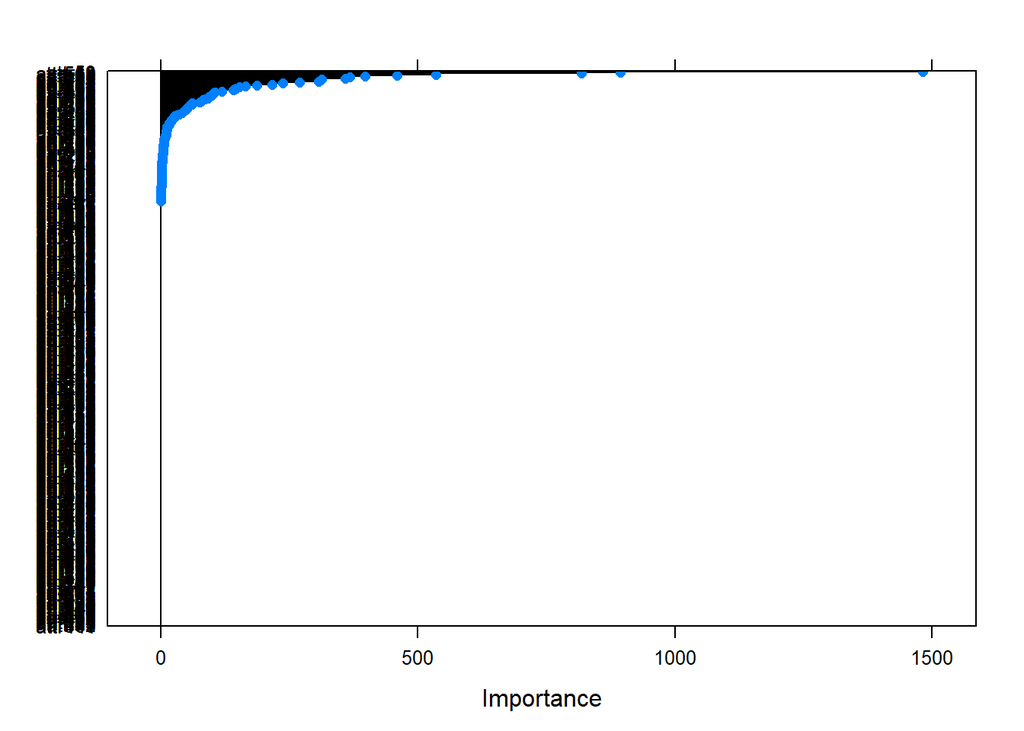

```r
plot(rankedImportance)
```

```r
# Set the importance threshold and calculate the list of attributes that don't contribute to the importance threshold
maxThreshold <- 0.99
rankedAttributes <- rankedImportance$importance
rankedAttributes <- rankedAttributes[order(-rankedAttributes$Overall),,drop=FALSE]
totalWeight <- sum(rankedAttributes)
i <- 1
accumWeight <- 0
exit_now <- FALSE
while ((i <= totAttr) & !exit_now) {
  accumWeight = accumWeight + rankedAttributes[i,]
  if ((accumWeight/totalWeight) >= maxThreshold) {
    exit_now <- TRUE
  } else {
    i <- i + 1
  }
}
lowImportance <- rankedAttributes[(i+1):(totAttr),,drop=FALSE]
lowAttributes <- rownames(lowImportance)
cat('Number of attributes contributed to the importance threshold:',i)
```

```
## Number of attributes contributed to the importance threshold: 79
```

```r
cat('Number of attributes found to be of low importance:',length(lowAttributes))
```

```
## Number of attributes found to be of low importance: 482
```

```r
# Removing the unselected attributes from the training and validation dataframes
xy_train <- xy_train[, !(names(xy_train) %in% lowAttributes)]
xy_test <- xy_test[, !(names(xy_test) %in% lowAttributes)]
```

### 3.c) Data Transforms

```r
# Not applicable for this iteration of the project.
```

### 3.d) Split-out training and validation datasets

We create a training dataset (variable name “xy_train”) and a validation dataset (variable name “xy_test”).

```r
set.seed(seedNum)

# Create a list of the rows in the original dataset we can use for training
#training_index <- createDataPartition(xy_train$targetVar, p=0.70, list=FALSE)
# Use 70% of data to training and testing the models
#xy_train <- xy_train[training_index,]
# Select the remaining 30% of the data for validation
#xy_test <- xy_train[-training_index,]

dim(xy_train)
```

```
## [1] 7352   80
```

```r
dim(xy_test)
```

```
## [1] 2947   80
```

```r
proc.time()-startTimeScript
```

```
##     user   system  elapsed
## 10196.12   249.87 10449.56
```

## 4. Model and Evaluate Algorithms

After the data-prep, we next work on finding a workable model by evaluating a subset of machine learning algorithms that are good at exploiting the structure of the training. The typical evaluation tasks include:

- Defining test options such as cross validation and the evaluation metric to use.
- Spot checking a suite of linear and nonlinear machine learning algorithms.
- Comparing the estimated accuracy of algorithms.

For this project, we will evaluate one linear, three non-linear, and three ensemble algorithms:

Linear Algorithm: Linear Discriminant Analysis

Non-Linear Algorithms: Decision Trees (CART), k-Nearest Neighbors, and Support Vector Machine

Ensemble Algorithms: Bagged CART, Random Forest, and Stochastic Gradient Boosting

The random number seed is reset before each run to ensure that the evaluation of each algorithm is performed using the same data splits. It ensures the results are directly comparable.

### 4.a) Generate models using linear algorithms

```r
# Linear Discriminant Analysis (Classification)
startTimeModule <- proc.time()
set.seed(seedNum)
fit.lda <- train(targetVar~., data=xy_train, method="lda", metric=metricTarget, trControl=control)
print(fit.lda)
```

```
## Linear Discriminant Analysis
##
## 7352 samples
##   79 predictor
##    6 classes: '1', '2', '3', '4', '5', '6'
##
## No pre-processing
## Resampling: Cross-Validated (10 fold, repeated 3 times)
## Summary of sample sizes: 6619, 6617, 6616, 6618, 6615, 6617, ...
## Resampling results:
##
##   Accuracy   Kappa
##   0.9482169  0.9376584
```

```r
proc.time()-startTimeModule
```

```
##    user  system elapsed
##    7.91    1.89    9.81
```

### 4.b) Generate models using nonlinear algorithms

```r
# Decision Tree - CART (Regression/Classification)
startTimeModule <- proc.time()
set.seed(seedNum)
fit.cart <- train(targetVar~., data=xy_train, method="rpart", metric=metricTarget, trControl=control)
print(fit.cart)
```

```
## CART
##
## 7352 samples
##   79 predictor
##    6 classes: '1', '2', '3', '4', '5', '6'
##
## No pre-processing
## Resampling: Cross-Validated (10 fold, repeated 3 times)
## Summary of sample sizes: 6619, 6617, 6616, 6618, 6615, 6617, ...
## Resampling results across tuning parameters:
##
##   cp         Accuracy   Kappa
##   0.1663583  0.6134572  0.5298896
##   0.2062237  0.4500256  0.3257090
##   0.2311186  0.2969719  0.1328365
##
## Accuracy was used to select the optimal model using the largest value.
## The final value used for the model was cp = 0.1663583.
```

```r
proc.time()-startTimeModule
```

```
##    user  system elapsed
##   12.38    0.50   12.91
```

```r
# k-Nearest Neighbors (Regression/Classification)
startTimeModule <- proc.time()
set.seed(seedNum)
fit.knn <- train(targetVar~., data=xy_train, method="knn", metric=metricTarget, trControl=control)
print(fit.knn)
```

```
## k-Nearest Neighbors
##
## 7352 samples
##   79 predictor
##    6 classes: '1', '2', '3', '4', '5', '6'
##
## No pre-processing
## Resampling: Cross-Validated (10 fold, repeated 3 times)
## Summary of sample sizes: 6619, 6617, 6616, 6618, 6615, 6617, ...
## Resampling results across tuning parameters:
##
##   k  Accuracy   Kappa
##   5  0.9635000  0.9560565
##   7  0.9622758  0.9545795
##   9  0.9622301  0.9545241
##
## Accuracy was used to select the optimal model using the largest value.
## The final value used for the model was k = 5.
```

```r
proc.time()-startTimeModule
```

```
##    user  system elapsed
##   51.59    1.03   52.64
```

```r
# Support Vector Machine (Regression/Classification)
startTimeModule <- proc.time()
set.seed(seedNum)
fit.svm <- train(targetVar~., data=xy_train, method="svmRadial", metric=metricTarget, trControl=control)
print(fit.svm)
```

```
## Support Vector Machines with Radial Basis Function Kernel
##
## 7352 samples
##   79 predictor
##    6 classes: '1', '2', '3', '4', '5', '6'
##
## No pre-processing
## Resampling: Cross-Validated (10 fold, repeated 3 times)
## Summary of sample sizes: 6619, 6617, 6616, 6618, 6615, 6617, ...
## Resampling results across tuning parameters:
##
##   C     Accuracy   Kappa
##   0.25  0.9610954  0.9531660
##   0.50  0.9649958  0.9578631
##   1.00  0.9686237  0.9622308
##
## Tuning parameter 'sigma' was held constant at a value of 0.01438469
## Accuracy was used to select the optimal model using the largest value.
## The final values used for the model were sigma = 0.01438469 and C = 1.
```

```r
proc.time()-startTimeModule
```

```
##    user  system elapsed
##  329.51    4.61  334.16
```

### 4.c) Generate models using ensemble algorithms

In this section, we will explore the use and tuning of ensemble algorithms to see whether we can improve the results.

```r
# Bagged CART (Regression/Classification)
startTimeModule <- proc.time()
set.seed(seedNum)
fit.bagcart <- train(targetVar~., data=xy_train, method="treebag", metric=metricTarget, trControl=control)
print(fit.bagcart)
```

```
## Bagged CART
##
## 7352 samples
##   79 predictor
##    6 classes: '1', '2', '3', '4', '5', '6'
##
## No pre-processing
## Resampling: Cross-Validated (10 fold, repeated 3 times)
## Summary of sample sizes: 6619, 6617, 6616, 6618, 6615, 6617, ...
## Resampling results:
##
##   Accuracy   Kappa
##   0.9745187  0.9693268
```

```r
proc.time()-startTimeModule
```

```
##    user  system elapsed
##  324.05    7.61  331.73
```

```r
# Random Forest (Regression/Classification)
startTimeModule <- proc.time()
set.seed(seedNum)
fit.rf <- train(targetVar~., data=xy_train, method="rf", metric=metricTarget, trControl=control)
print(fit.rf)
```

```
## Random Forest
##
## 7352 samples
##   79 predictor
##    6 classes: '1', '2', '3', '4', '5', '6'
##
## No pre-processing
## Resampling: Cross-Validated (10 fold, repeated 3 times)
## Summary of sample sizes: 6619, 6617, 6616, 6618, 6615, 6617, ...
## Resampling results across tuning parameters:
##
##   mtry  Accuracy   Kappa
##    2    0.9861249  0.9832983
##   40    0.9804586  0.9764779
##   79    0.9765604  0.9717843
##
## Accuracy was used to select the optimal model using the largest value.
## The final value used for the model was mtry = 2.
```

```r
proc.time()-startTimeModule
```

```
##    user  system elapsed
## 2341.53   20.31 2362.09
```

```r
# Stochastic Gradient Boosting (Regression/Classification)
startTimeModule <- proc.time()
set.seed(seedNum)
fit.gbm <- train(targetVar~., data=xy_train, method="gbm", metric=metricTarget, trControl=control, verbose=F)
print(fit.gbm)
```

```
## Stochastic Gradient Boosting
##
## 7352 samples
##   79 predictor
##    6 classes: '1', '2', '3', '4', '5', '6'
##
## No pre-processing
## Resampling: Cross-Validated (10 fold, repeated 3 times)
## Summary of sample sizes: 6619, 6617, 6616, 6618, 6615, 6617, ...
## Resampling results across tuning parameters:
##
##   interaction.depth  n.trees  Accuracy   Kappa
##   1                   50      0.9496286  0.9393598
##   1                  100      0.9694877  0.9632718
##   1                  150      0.9753345  0.9703092
##   2                   50      0.9716609  0.9658866
##   2                  100      0.9818631  0.9781680
##   2                  150      0.9855359  0.9825891
##   3                   50      0.9775564  0.9729835
##   3                  100      0.9863519  0.9835715
##   3                  150      0.9893893  0.9872277
##
## Tuning parameter 'shrinkage' was held constant at a value of 0.1
##
## Tuning parameter 'n.minobsinnode' was held constant at a value of 10
## Accuracy was used to select the optimal model using the largest value.
## The final values used for the model were n.trees = 150,
##  interaction.depth = 3, shrinkage = 0.1 and n.minobsinnode = 10.
```

```r
proc.time()-startTimeModule
```

```
##    user  system elapsed
## 1433.66    4.75 1438.61
```

### 4.d) Compare baseline algorithms

```r
results <- resamples(list(LDA=fit.lda, CART=fit.cart, kNN=fit.knn, SVM=fit.svm, BagCART=fit.bagcart, RF=fit.rf, GBM=fit.gbm))
summary(results)
```

```
##
## Call:
## summary.resamples(object = results)
##
## Models: LDA, CART, kNN, SVM, BagCART, RF, GBM
## Number of resamples: 30
##
## Accuracy
##              Min.   1st Qu.    Median      Mean   3rd Qu.      Max. NA's
## LDA     0.9346939 0.9418367 0.9470109 0.9482169 0.9523161 0.9647218    0
## CART    0.5435967 0.5454855 0.6641711 0.6134572 0.6739130 0.6784741    0
## kNN     0.9495913 0.9595800 0.9638973 0.9635000 0.9674576 0.9742198    0
## SVM     0.9578231 0.9649904 0.9687923 0.9686237 0.9715061 0.9782904    0
## BagCART 0.9631651 0.9690476 0.9747965 0.9745187 0.9792234 0.9864315    0
## RF      0.9782313 0.9836845 0.9863667 0.9861249 0.9887532 0.9945799    0
## GBM     0.9795918 0.9877551 0.9904502 0.9893893 0.9918561 0.9945578    0
##
## Kappa
##              Min.   1st Qu.    Median      Mean   3rd Qu.      Max. NA's
## LDA     0.9213736 0.9300040 0.9362091 0.9376584 0.9426062 0.9575314    0
## CART    0.4441908 0.4464486 0.5923597 0.5298896 0.6039890 0.6093764    0
## kNN     0.9393181 0.9513335 0.9565401 0.9560565 0.9608200 0.9689658    0
## SVM     0.9492274 0.9578574 0.9624324 0.9622308 0.9656983 0.9738699    0
## BagCART 0.9556592 0.9627472 0.9696559 0.9693268 0.9749922 0.9836635    0
## RF      0.9738019 0.9803616 0.9835891 0.9832983 0.9864608 0.9934755    0
## GBM     0.9754373 0.9852605 0.9885043 0.9872277 0.9901965 0.9934491    0
```

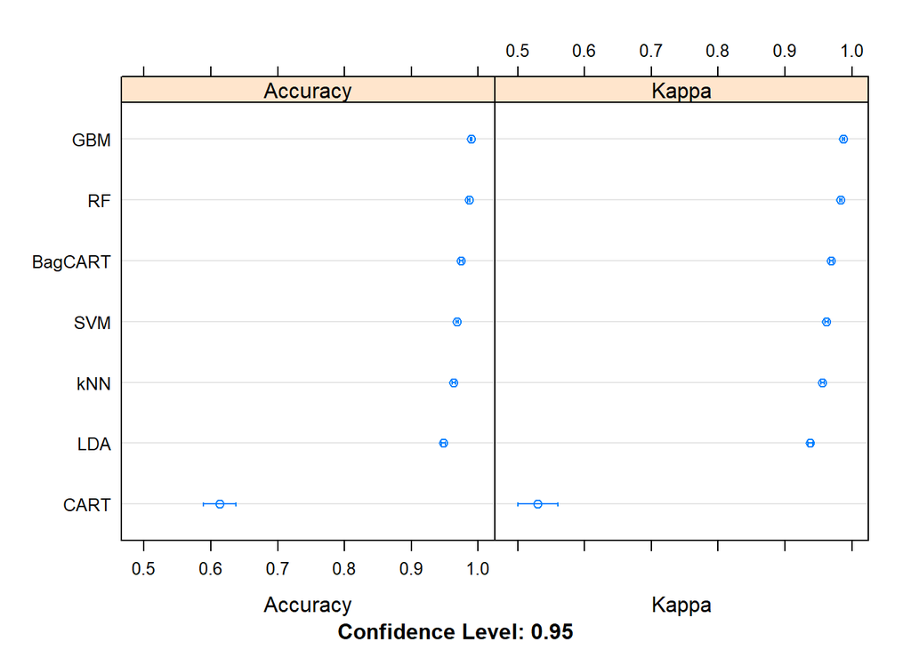

```r
dotplot(results)
```

```r
cat('The average accuracy from all models is:',
    mean(c(results$values$`LR~Accuracy`,results$values$`CART~Accuracy`,results$values$`kNN~Accuracy`,results$values$`SVM~Accuracy`,results$values$`BagCART~Accuracy`,results$values$`RF~Accuracy`,results$values$`GBM~Accuracy`)))
```

```
## The average accuracy from all models is: 0.9159356
```

## 5. Improve Accuracy or Results

After we achieve a short list of machine learning algorithms with good level of accuracy, we can leverage ways to improve the accuracy of the models.

Using the top two best-perfoming algorithms from the previous section, we will Search for a combination of parameters for each algorithm that yields the best results.

### 5.a) Algorithm Tuning

Finally, we will tune the best-performing algorithms from each group further and see whether we can get more accuracy out of them.

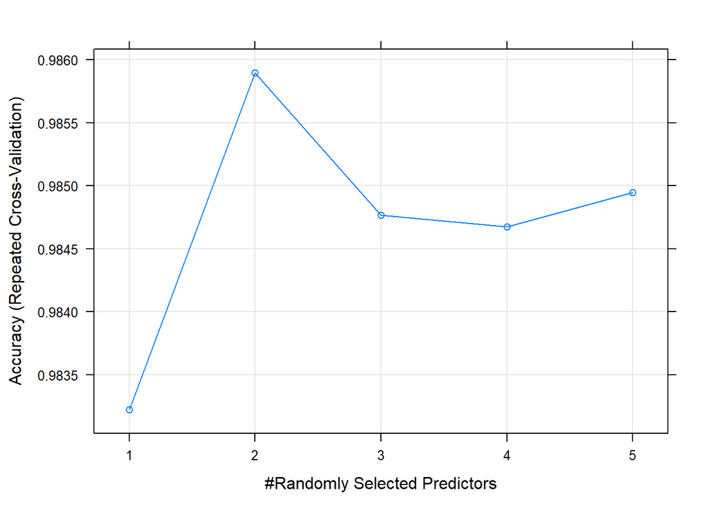

```r
# Tuning algorithm #1 - Random Forest
startTimeModule <- proc.time()
set.seed(seedNum)
grid <- expand.grid(mtry = c(1:5))
fit.final1 <- train(targetVar~., data=xy_train, method="rf", metric=metricTarget, tuneGrid=grid, trControl=control)
plot(fit.final1)
```

```r
print(fit.final1)
```

```
## Random Forest
##
## 7352 samples
##   79 predictor
##    6 classes: '1', '2', '3', '4', '5', '6'
##
## No pre-processing
## Resampling: Cross-Validated (10 fold, repeated 3 times)
## Summary of sample sizes: 6619, 6617, 6616, 6618, 6615, 6617, ...
## Resampling results across tuning parameters:
##
##   mtry  Accuracy   Kappa
##   1     0.9832219  0.9798036
##   2     0.9858980  0.9830250
##   3     0.9847650  0.9816614
##   4     0.9846746  0.9815527
##   5     0.9849468  0.9818805
##
## Accuracy was used to select the optimal model using the largest value.
## The final value used for the model was mtry = 2.
```

```r
proc.time()-startTimeModule
```

```
##    user  system elapsed
## 2494.39   33.05 2527.88
```

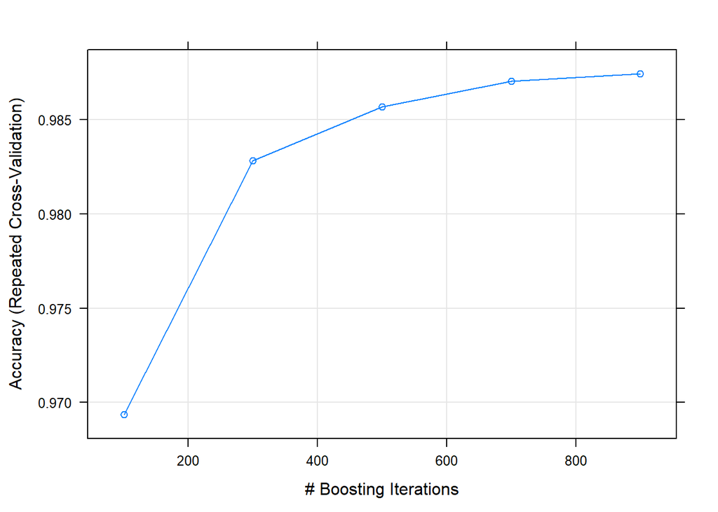

```r
# Tuning algorithm #2 - Stochastic Gradient Boosting
startTimeModule <- proc.time()
set.seed(seedNum)
grid <- expand.grid(.n.trees=c(100,300,500,700,900), .shrinkage=c(0.1), .interaction.depth=c(1), .n.minobsinnode=c(10))
fit.final2 <- train(targetVar~., data=xy_train, method="gbm", metric=metricTarget, tuneGrid=grid, trControl=control, verbose=F)
plot(fit.final2)
```

```r
print(fit.final2)
```

```
## Stochastic Gradient Boosting
##
## 7352 samples
##   79 predictor
##    6 classes: '1', '2', '3', '4', '5', '6'
##
## No pre-processing
## Resampling: Cross-Validated (10 fold, repeated 3 times)
## Summary of sample sizes: 6619, 6617, 6616, 6618, 6615, 6617, ...
## Resampling results across tuning parameters:
##
##   n.trees  Accuracy   Kappa
##   100      0.9693502  0.9631058
##   300      0.9828159  0.9793154
##   500      0.9856713  0.9827526
##   700      0.9870324  0.9843908
##   900      0.9874408  0.9848825
##
## Tuning parameter 'interaction.depth' was held constant at a value of
##  1
## Tuning parameter 'shrinkage' was held constant at a value of 0.1
##
## Tuning parameter 'n.minobsinnode' was held constant at a value of 10
## Accuracy was used to select the optimal model using the largest value.
## The final values used for the model were n.trees = 900,
##  interaction.depth = 1, shrinkage = 0.1 and n.minobsinnode = 10.
```

```r
proc.time()-startTimeModule
```

```
##    user  system elapsed
## 1674.83    7.95 1683.02
```

### 5.d) Compare Algorithms After Tuning

```r
results <- resamples(list(RF=fit.final1, GBM=fit.final2))
summary(results)
```

```
##
## Call:
## summary.resamples(object = results)
##
## Models: RF, GBM
## Number of resamples: 30
##
## Accuracy
##          Min.   1st Qu.    Median      Mean   3rd Qu.      Max. NA's
## RF  0.9795918 0.9836568 0.9857050 0.9858980 0.9877551 0.9959350    0
## GBM 0.9755102 0.9850340 0.9877384 0.9874408 0.9891415 0.9959239    0
##
## Kappa
##          Min.   1st Qu.    Median      Mean  3rd Qu.      Max. NA's
## RF  0.9754380 0.9803282 0.9827925 0.9830250 0.985261 0.9951067    0
## GBM 0.9705267 0.9819854 0.9852418 0.9848825 0.986930 0.9950935    0
```

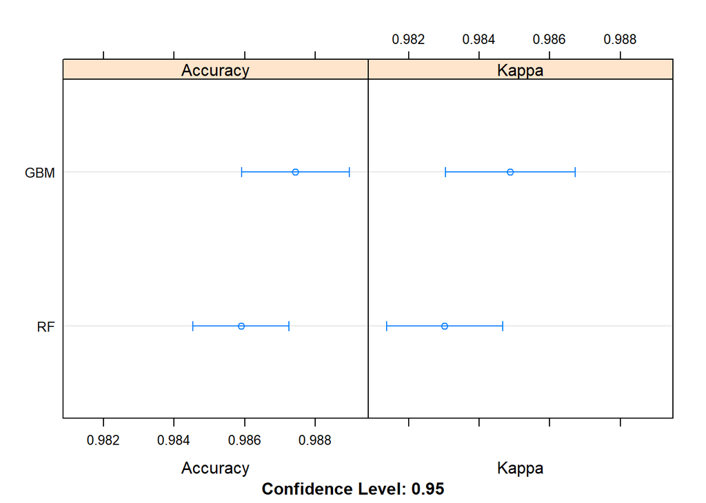

```r
dotplot(results)
```

## 6. Finalize Model and Present Results

Once we have narrow down to a model that we believe can make accurate predictions on unseen data, we are ready to finalize it. Finalizing a model may involve sub-tasks such as:

- Using an optimal model tuned to make predictions on unseen data.
- Creating a standalone model using the tuned parameters
- Saving an optimal model to file for later use.

### 6.a) Predictions on validation dataset

```r
predictions <- predict(fit.final2, newdata=xy_test)
confusionMatrix(predictions, xy_test$targetVar)
```

```
## Confusion Matrix and Statistics
##
##           Reference
## Prediction   1   2   3   4   5   6
##          1 487  54   8   0   0   0
##          2   6 410  25   2   0   0
##          3   3   5 383   0   0   0
##          4   0   0   0 429  25   0
##          5   0   2   4  60 507   0
##          6   0   0   0   0   0 537
##
## Overall Statistics
##
##                Accuracy : 0.9342
##                  95% CI : (0.9246, 0.9429)
##     No Information Rate : 0.1822
##     P-Value [Acc > NIR] : < 2.2e-16
##
##                   Kappa : 0.9209
##  Mcnemar's Test P-Value : NA
##
## Statistics by Class:
##
##                      Class: 1 Class: 2 Class: 3 Class: 4 Class: 5 Class: 6
## Sensitivity            0.9819   0.8705   0.9119   0.8737   0.9530   1.0000
## Specificity            0.9747   0.9867   0.9968   0.9898   0.9727   1.0000
## Pos Pred Value         0.8871   0.9255   0.9795   0.9449   0.8848   1.0000
## Neg Pred Value         0.9962   0.9756   0.9855   0.9751   0.9895   1.0000
## Prevalence             0.1683   0.1598   0.1425   0.1666   0.1805   0.1822
## Detection Rate         0.1653   0.1391   0.1300   0.1456   0.1720   0.1822
## Detection Prevalence   0.1863   0.1503   0.1327   0.1541   0.1944   0.1822
## Balanced Accuracy      0.9783   0.9286   0.9544   0.9318   0.9628   1.0000
```

### 6.b) Create standalone model on entire training dataset

```r
startTimeModule <- proc.time()
library(gbm)
set.seed(seedNum)
finalModel <- gbm(targetVar~., data=xy_train, n.trees=900, verbose=F)
```

```
## Distribution not specified, assuming multinomial ...
```

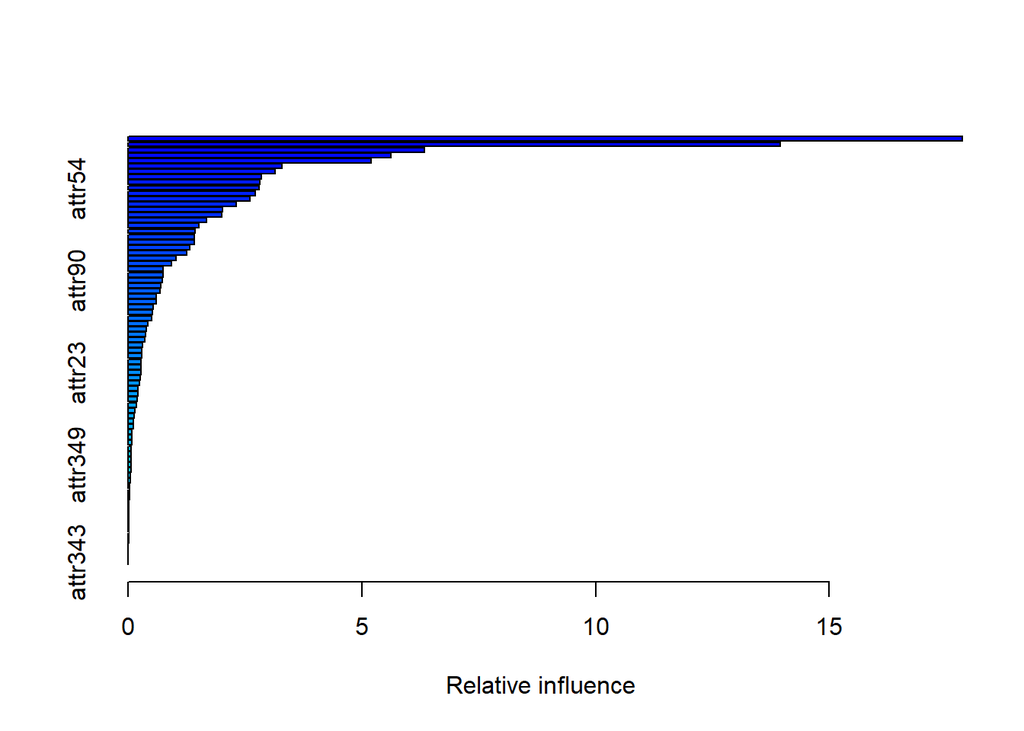

```
##             var      rel.inf
## attr53   attr53 17.841764282
## attr41   attr41 13.942073087
## attr505 attr505  6.343974054
## attr10   attr10  5.619046258
## attr560 attr560  5.197592452
## attr275 attr275  3.290270411
## attr130 attr130  3.140601278
## attr167 attr167  2.852510520
## attr202 attr202  2.816228902
## attr54   attr54  2.802350277
## attr317 attr317  2.721614680
## attr297 attr297  2.609344714
## attr451 attr451  2.310254961
## attr331 attr331  2.022782525
## attr538 attr538  2.013962066
## attr139 attr139  1.679709408
## attr503 attr503  1.512858286
## attr412 attr412  1.432921143
## attr519 attr519  1.424995397
## attr51   attr51  1.422647371
## attr372 attr372  1.320242024
## attr42   attr42  1.250448640
## attr303 attr303  1.022509699
## attr509 attr509  0.937472004
## attr433 attr433  0.753851515
## attr296 attr296  0.744584553
## attr90   attr90  0.738893253
## attr370 attr370  0.706545577
## attr430 attr430  0.685731167
## attr58   attr58  0.597062910
## attr103 attr103  0.597015925
## attr375 attr375  0.540159376
## attr136 attr136  0.524603196
## attr133 attr133  0.499881386
## attr70   attr70  0.421594991
## attr38   attr38  0.390037928
## attr140 attr140  0.371567544
## attr210 attr210  0.362917561
## attr207 attr207  0.309288933
```

[output cut: 25 more lines]

```
## attr14   attr14  0.041632493
## attr199 attr199  0.029267764
## attr561 attr561  0.028109585
## attr75   attr75  0.022111561
## attr420 attr420  0.021071995
## attr52   attr52  0.020435338
## attr71   attr71  0.019891756
## attr383 attr383  0.018390454
## attr74   attr74  0.018196930
## attr20   attr20  0.017613448
## attr513 attr513  0.017137249
## attr234 attr234  0.006039110
## attr127 attr127  0.003454736
## attr201 attr201  0.000000000
## attr343 attr343  0.000000000
```

```r
summary(finalModel)
```

```r
proc.time()-startTimeModule
```

```
##    user  system elapsed
##   59.83    0.25   60.08
```

### 6.c) Save model for later use

```r
#saveRDS(finalModel, "./finalModel_MultiClass.rds")
```

```r
proc.time()-startTimeScript
```

```
##     user   system  elapsed
## 18929.26   332.33 19266.55
```